# Analysis: survey

Gamified Feedback in Adaptive Retrieval Practice

Maarten van der Velde & Gesa van den Broek

Last updated: 2024-07-11

# Setup

```r
library(here)
library(dplyr)
library(ggplot2)
library(scales)
library(patchwork)
library(stringr)
library(tidyr)
library(lme4)
library(lmerTest)
```

Helper functions for plots and tables:

```r
source(here("scripts", "00_visualisation_functions.R"))
```

Load processed data:

```r
d_survey <- readRDS(here("data", "processed", "d_survey.rds"))
```

```r
add_experiment_cols <- function (data) {
  data |>
    mutate(exp_order = case_when(
      gamified_first == 0 & exp_group == "score" ~ "Control—Score",
      gamified_first == 0 & exp_group == "both" ~ "Control—Both",
      gamified_first == 1 & exp_group == "score" ~ "Score—Control",
      gamified_first == 1 & exp_group == "both" ~ "Both—Control"
    )) |>
    mutate(type = ifelse(gamified, "Gamified", "Control"))
}
```

# Does gamification change task-motivational outcomes?

Relevant variables: Feelings of competence, Enjoyment, task value, and task preference.

Prepare data

```r
d_survey_agg <- d_survey |>
  group_by(block, condition, gamified, gamified_first, exp_group, category, question) |>
  summarise(response_mean = mean(response, na.rm = T),
            response_se = sd(response, na.rm = T)/sqrt(n())) |>
  ungroup() |>
  add_experiment_cols() |>
  mutate(perception_label_sorted = factor(question, levels = c("goalsetting","performwell","goalstress","distraction","relevance")))
```

[output not shown]

Mean-centering categorical predictors for modelling:

```r
d_survey_m <- d_survey |>
  mutate(exp_group_c = ifelse(exp_group == "score", 0, 1),
         exp_group_c = exp_group_c - mean(exp_group_c),
         gamified_first_c = gamified_first - mean(gamified_first))
```

## Combined plot

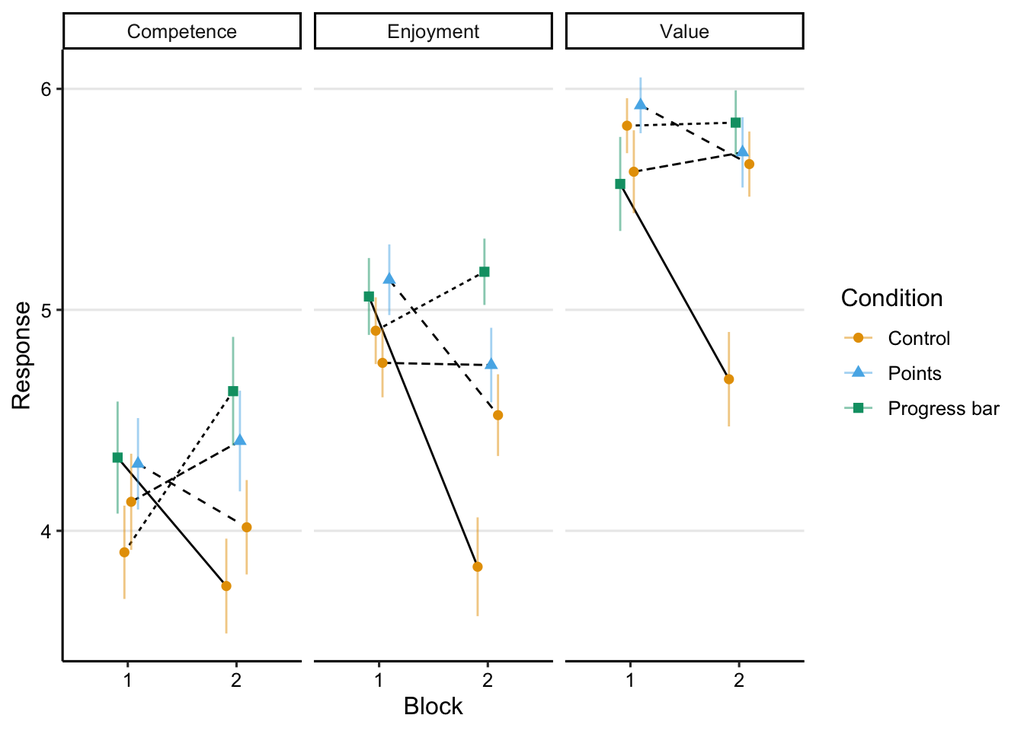

```r
dodge_width <- .25

p_motivation <- d_survey_agg |>
  filter(category == "motivation") |>
  ggplot(aes(x = block, y = response_mean, group = interaction(exp_order, question))) +
  facet_grid(~ question, labeller = labeller(question = str_to_title)) +
  geom_line(aes(lty = exp_order), position = position_dodge(width = dodge_width)) +
  geom_errorbar(aes(ymin = response_mean - response_se, ymax = response_mean + response_se, colour = condition),
                width = 0,
                alpha = .5,
                position = position_dodge(width = dodge_width)) +
  geom_point(aes(colour = condition, pch = condition),
             size = 2,
             position = position_dodge(width = dodge_width)) +
  scale_y_continuous(breaks = 1:7) +
  scale_colour_manual(values = col_condition) +
  guides(lty = "none") +
  labs(x = "Block",
       y = "Response",
       colour = "Condition",
       pch = "Condition") +
  theme_paper

p_motivation
```

```r
ggsave(p_motivation, filename = here("output", "survey_motivation.png"), width = 8, height = 3)
```

## Competence

### Fit model

```r
m_competence <- lmer(response ~ gamified +
                       gamified:exp_group_c +
                       gamified:gamified_first_c +
                       gamified:gamified_first_c:exp_group_c +
                       (1 | subject),
                     data = filter(d_survey_m, question == "competence"))

summary(m_competence)
```

```
Linear mixed model fit by REML. t-tests use Satterthwaite's method [
lmerModLmerTest]
Formula:
response ~ gamified + gamified:exp_group_c + gamified:gamified_first_c +
    gamified:gamified_first_c:exp_group_c + (1 | subject)
   Data: filter(d_survey_m, question == "competence")

REML criterion at convergence: 1119.5

Scaled residuals:
     Min       1Q   Median       3Q      Max
-2.32430 -0.51027  0.00453  0.51192  2.02550

Random effects:
 Groups   Name        Variance Std.Dev.
 subject  (Intercept) 1.2298   1.1090
 Residual             0.8614   0.9281
Number of obs: 332, groups:  subject, 166

Fixed effects:
                                            Estimate Std. Error        df
(Intercept)                                  3.95034    0.11224 240.74459
gamifiedTRUE                                 0.45649    0.10188 162.00000
gamifiedFALSE:exp_group_c                   -0.24880    0.22474 240.74459
gamifiedTRUE:exp_group_c                     0.11862    0.22474 240.74459
gamifiedFALSE:gamified_first_c              -0.13313    0.22528 240.74459
gamifiedTRUE:gamified_first_c               -0.19704    0.22528 240.74459
gamifiedFALSE:exp_group_c:gamified_first_c  -0.03749    0.45111 240.74459
gamifiedTRUE:exp_group_c:gamified_first_c   -0.19749    0.45111 240.74459
                                           t value Pr(>|t|)
(Intercept)                                 35.195  < 2e-16 ***
gamifiedTRUE                                 4.481  1.4e-05 ***
gamifiedFALSE:exp_group_c                   -1.107    0.269
gamifiedTRUE:exp_group_c                     0.528    0.598
gamifiedFALSE:gamified_first_c              -0.591    0.555
gamifiedTRUE:gamified_first_c               -0.875    0.383
gamifiedFALSE:exp_group_c:gamified_first_c  -0.083    0.934
gamifiedTRUE:exp_group_c:gamified_first_c   -0.438    0.662
---
Signif. codes:  0 '***' 0.001 '**' 0.01 '*' 0.05 '.' 0.1 ' ' 1

Correlation of Fixed Effects:
              (Intr) gmTRUE gmfdFALSE:x__ gmfdTRUE:x__ gmfdFALSE:g__
gamifidTRUE   -0.454
gmfdFALSE:x__  0.000  0.000
gmfdTRUE:x__   0.000  0.000  0.588
gmfdFALSE:g__  0.000  0.000 -0.004        -0.002
gmfdTRUE:g__   0.000  0.000 -0.002        -0.004        0.588
gFALSE:__:_   -0.004  0.002  0.000         0.000        0.001
gTRUE:__:__   -0.002 -0.002  0.000         0.000        0.000
              gmfdTRUE:g__ gFALSE:__:
gamifidTRUE
gmfdFALSE:x__
gmfdTRUE:x__
gmfdFALSE:g__
gmfdTRUE:g__
gFALSE:__:_    0.000
gTRUE:__:__    0.001        0.588
```

```r
print_model_table(m_competence)
```

| Effect | Estimate | SE | df | t-value | p-value |
| --- | --- | --- | --- | --- | --- |
| Intercept (Control) | 3.950 | 0.112 | 240.74 | 35.20 | <.001 |
| Gamification | 0.456 | 0.102 | 162.00 | 4.48 | <.001 |
| Type of gamification (Progress bar - Points) | 0.119 | 0.225 | 240.74 | 0.53 | .598 |
| Type of gamification on Control (Progress bar - Points) | -0.249 | 0.225 | 240.74 | -1.11 | .269 |
| Block on gamification (1 - 2) | -0.197 | 0.225 | 240.74 | -0.87 | .383 |
| Block on Control (2 - 1) | -0.133 | 0.225 | 240.74 | -0.59 | .555 |
| Type of gamification; block difference (Block 1 - Block 2) | -0.197 | 0.451 | 240.74 | -0.44 | .662 |
| Type of gamification on Control; block difference (Block 2 - Block 1) | -0.037 | 0.451 | 240.74 | -0.08 | .934 |

### Fitted values

```r
d_model_fit <- crossing(
  gamified = c(TRUE, FALSE),
  exp_group_c = 0,
  gamified_first_c = 0
)

d_model_fit$model_fit <- predict(m_competence,
                                 newdata = d_model_fit,
                                 re.form = NA,
                                 type = "response")

d_model_fit
```

| gamified | exp_group_c | gamified_first_c | model_fit |
| --- | --- | --- | --- |
| FALSE | 0 | 0 | 3.950339 |
| TRUE | 0 | 0 | 4.406827 |

### Visualise fitted model

```r
p_competence_m <- plot_model_fit(m_competence, filter(d_survey_m, question == "competence"), y_lab = "Competence") +
  scale_y_continuous(limits = c(3, 6), labels = scales::comma_format())
```

```
  block    condition gamified gamified_first exp_group gamified_first_c
1     1      Control    FALSE          FALSE      both       -0.5421687
2     1      Control    FALSE          FALSE     score       -0.5421687
3     1       Points     TRUE           TRUE     score        0.4578313
4     1 Progress bar     TRUE           TRUE      both        0.4578313
5     2      Control    FALSE           TRUE      both        0.4578313
6     2      Control    FALSE           TRUE     score        0.4578313
7     2       Points     TRUE          FALSE     score       -0.5421687
8     2 Progress bar     TRUE          FALSE      both       -0.5421687
  exp_group_c pred_val     exp_order     type
1   0.5240964 3.902778  Control—Both  Control
2  -0.4759036 4.131250 Control—Score  Control
3  -0.4759036 4.303191 Score—Control Gamified
4   0.5240964 4.331395  Both—Control Gamified
5   0.5240964 3.750000  Both—Control  Control
6  -0.4759036 4.015957 Score—Control  Control
7  -0.4759036 4.406250 Control—Score Gamified
8   0.5240964 4.631944  Control—Both Gamified
```

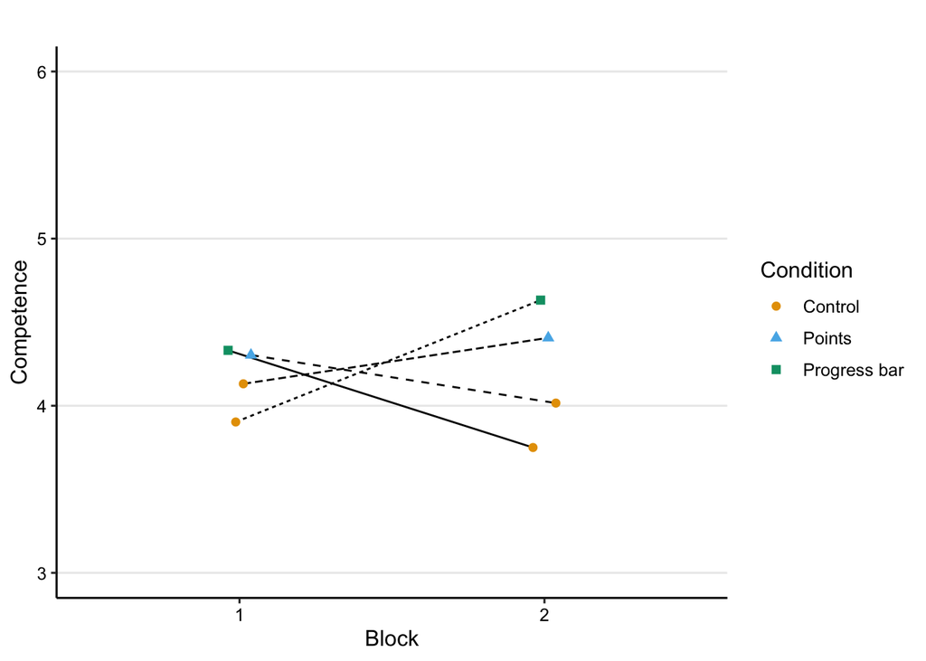

```r
p_competence_m
```

## Enjoyment

### Fit model

```r
m_enjoyment <- lmer(response ~ gamified +
                      gamified:exp_group_c +
                      gamified:gamified_first_c +
                      gamified:gamified_first_c:exp_group_c +
                      (1 | subject),
                    data = filter(d_survey_m, question == "enjoyment"))

summary(m_enjoyment)
```

```
Linear mixed model fit by REML. t-tests use Satterthwaite's method [
lmerModLmerTest]
Formula:
response ~ gamified + gamified:exp_group_c + gamified:gamified_first_c +
    gamified:gamified_first_c:exp_group_c + (1 | subject)
   Data: filter(d_survey_m, question == "enjoyment")

REML criterion at convergence: 923.4

Scaled residuals:
     Min       1Q   Median       3Q      Max
-2.28644 -0.46853  0.04077  0.45253  2.13674

Random effects:
 Groups   Name        Variance Std.Dev.
 subject  (Intercept) 0.8818   0.9391
 Residual             0.3950   0.6285
Number of obs: 332, groups:  subject, 166

Fixed effects:
                                            Estimate Std. Error        df
(Intercept)                                  4.48639    0.08770 219.36009
gamifiedTRUE                                 0.54544    0.06898 162.00000
gamifiedFALSE:exp_group_c                   -0.30539    0.17561 219.36009
gamifiedTRUE:exp_group_c                     0.15226    0.17561 219.36009
gamifiedFALSE:gamified_first_c              -0.63243    0.17603 219.36009
gamifiedTRUE:gamified_first_c                0.14920    0.17603 219.36009
gamifiedFALSE:exp_group_c:gamified_first_c  -0.83175    0.35248 219.36009
gamifiedTRUE:exp_group_c:gamified_first_c   -0.49793    0.35248 219.36009
                                           t value Pr(>|t|)
(Intercept)                                 51.155  < 2e-16 ***
gamifiedTRUE                                 7.907 3.86e-13 ***
gamifiedFALSE:exp_group_c                   -1.739 0.083428 .
gamifiedTRUE:exp_group_c                     0.867 0.386862
gamifiedFALSE:gamified_first_c              -3.593 0.000404 ***
gamifiedTRUE:gamified_first_c                0.848 0.397584
gamifiedFALSE:exp_group_c:gamified_first_c  -2.360 0.019168 *
gamifiedTRUE:exp_group_c:gamified_first_c   -1.413 0.159185
---
Signif. codes:  0 '***' 0.001 '**' 0.01 '*' 0.05 '.' 0.1 ' ' 1

Correlation of Fixed Effects:
              (Intr) gmTRUE gmfdFALSE:x__ gmfdTRUE:x__ gmfdFALSE:g__
gamifidTRUE   -0.393
gmfdFALSE:x__  0.000  0.000
gmfdTRUE:x__   0.000  0.000  0.691
gmfdFALSE:g__  0.000  0.000 -0.004        -0.003
gmfdTRUE:g__   0.000  0.000 -0.003        -0.004        0.691
gFALSE:__:_   -0.004  0.002  0.000         0.000        0.001
gTRUE:__:__   -0.003 -0.002  0.000         0.000        0.000
              gmfdTRUE:g__ gFALSE:__:
gamifidTRUE
gmfdFALSE:x__
gmfdTRUE:x__
gmfdFALSE:g__
gmfdTRUE:g__
gFALSE:__:_    0.000
gTRUE:__:__    0.001        0.691
```

```r
print_model_table(m_enjoyment)
```

| Effect | Estimate | SE | df | t-value | p-value |
| --- | --- | --- | --- | --- | --- |
| Intercept (Control) | 4.486 | 0.088 | 219.36 | 51.15 | <.001 |
| Gamification | 0.545 | 0.069 | 162.00 | 7.91 | <.001 |
| Type of gamification (Progress bar - Points) | 0.152 | 0.176 | 219.36 | 0.87 | .387 |
| Type of gamification on Control (Progress bar - Points) | -0.305 | 0.176 | 219.36 | -1.74 | .083 |
| Block on gamification (1 - 2) | 0.149 | 0.176 | 219.36 | 0.85 | .398 |
| Block on Control (2 - 1) | -0.632 | 0.176 | 219.36 | -3.59 | <.001 |
| Type of gamification; block difference (Block 1 - Block 2) | -0.498 | 0.352 | 219.36 | -1.41 | .159 |
| Type of gamification on Control; block difference (Block 2 - Block 1) | -0.832 | 0.352 | 219.36 | -2.36 | .019 |

### Fitted values

```r
d_model_fit <- crossing(
  gamified = c(TRUE, FALSE),
  exp_group_c = 0,
  gamified_first_c = 0
)

d_model_fit$model_fit <- predict(m_enjoyment,
                                 newdata = d_model_fit,
                                 re.form = NA,
                                 type = "response")

d_model_fit
```

| gamified | exp_group_c | gamified_first_c | model_fit |
| --- | --- | --- | --- |
| FALSE | 0 | 0 | 4.486387 |
| TRUE | 0 | 0 | 5.031831 |

```r
d_model_fit <- crossing(
  gamified = FALSE,
  exp_group_c = 0,
  gamified_first_c = sort(unique(d_survey_m$gamified_first_c))
)

d_model_fit$model_fit <- predict(m_enjoyment,
                                 newdata = d_model_fit,
                                 re.form = NA,
                                 type = "response")

d_model_fit
```

| gamified | exp_group_c | gamified_first_c | model_fit |
| --- | --- | --- | --- |
| FALSE | 0 | -0.5421687 | 4.829270 |
| FALSE | 0 | 0.4578313 | 4.196842 |

```r
d_model_fit <- crossing(
  gamified = FALSE,
  exp_group_c = sort(unique(d_survey_m$exp_group_c)),
  gamified_first_c = sort(unique(d_survey_m$gamified_first_c))
)

d_model_fit$model_fit <- predict(m_enjoyment,
                                 newdata = d_model_fit,
                                 re.form = NA,
                                 type = "response")

d_model_fit
```

| gamified | exp_group_c | gamified_first_c | model_fit |
| --- | --- | --- | --- |
| FALSE | -0.4759036 | -0.5421687 | 4.760000 |
| FALSE | -0.4759036 | 0.4578313 | 4.523404 |
| FALSE | 0.5240964 | -0.5421687 | 4.905556 |
| FALSE | 0.5240964 | 0.4578313 | 3.837209 |

### Visualise fitted model

```r
p_enjoyment_m <- plot_model_fit(m_enjoyment, filter(d_survey_m, question == "enjoyment"), y_lab = "Enjoyment") +
  scale_y_continuous(limits = c(3, 6), labels = scales::comma_format())
```

```
  block    condition gamified gamified_first exp_group gamified_first_c
1     1      Control    FALSE          FALSE      both       -0.5421687
2     1      Control    FALSE          FALSE     score       -0.5421687
3     1       Points     TRUE           TRUE     score        0.4578313
4     1 Progress bar     TRUE           TRUE      both        0.4578313
5     2      Control    FALSE           TRUE      both        0.4578313
6     2      Control    FALSE           TRUE     score        0.4578313
7     2       Points     TRUE          FALSE     score       -0.5421687
8     2 Progress bar     TRUE          FALSE      both       -0.5421687
  exp_group_c pred_val     exp_order     type
1   0.5240964 4.905556  Control—Both  Control
2  -0.4759036 4.760000 Control—Score  Control
3  -0.4759036 5.136170 Score—Control Gamified
4   0.5240964 5.060465  Both—Control Gamified
5   0.5240964 3.837209  Both—Control  Control
6  -0.4759036 4.523404 Score—Control  Control
7  -0.4759036 4.750000 Control—Score Gamified
8   0.5240964 5.172222  Control—Both Gamified
```

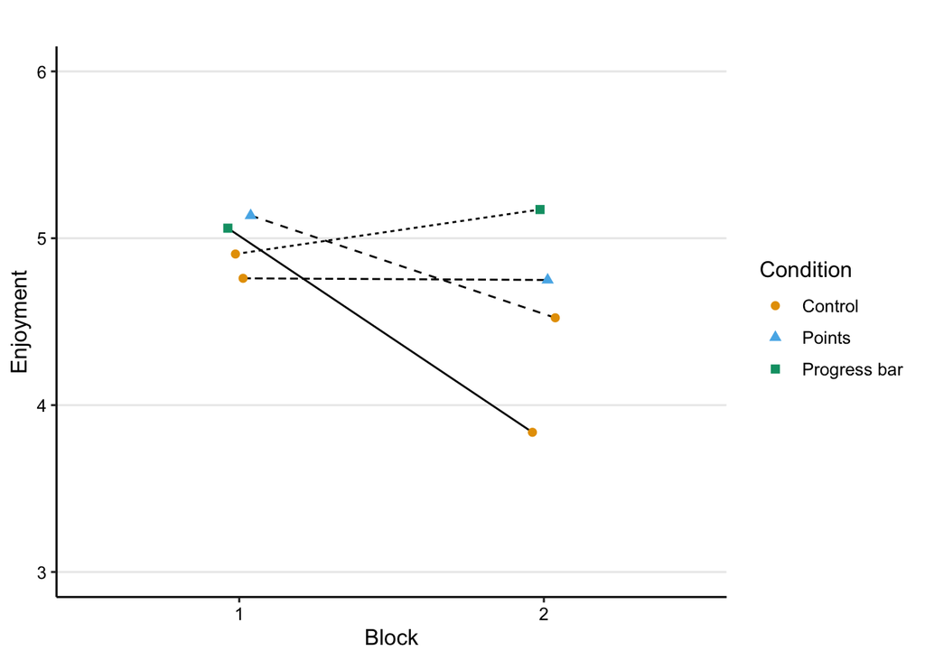

```r
p_enjoyment_m
```

## Perceived Task Value

### Fit model

```r
m_value <- lmer(response ~ gamified +
                       gamified:exp_group_c +
                       gamified:gamified_first_c +
                       gamified:gamified_first_c:exp_group_c +
                       (1 | subject),
                     data = filter(d_survey_m, question == "value"))

summary(m_value)
```

```
Linear mixed model fit by REML. t-tests use Satterthwaite's method [
lmerModLmerTest]
Formula:
response ~ gamified + gamified:exp_group_c + gamified:gamified_first_c +
    gamified:gamified_first_c:exp_group_c + (1 | subject)
   Data: filter(d_survey_m, question == "value")

REML criterion at convergence: 911.9

Scaled residuals:
     Min       1Q   Median       3Q      Max
-2.96908 -0.46010  0.04555  0.52620  2.10776

Random effects:
 Groups   Name        Variance Std.Dev.
 subject  (Intercept) 0.7933   0.8907
 Residual             0.3998   0.6323
Number of obs: 332, groups:  subject, 166

Fixed effects:
                                            Estimate Std. Error        df
(Intercept)                                  5.43795    0.08478 224.66834
gamifiedTRUE                                 0.32761    0.06940 162.00000
gamifiedFALSE:exp_group_c                   -0.43243    0.16976 224.66834
gamifiedTRUE:exp_group_c                    -0.13120    0.16976 224.66834
gamifiedFALSE:gamified_first_c              -0.52788    0.17017 224.66834
gamifiedTRUE:gamified_first_c               -0.02039    0.17017 224.66834
gamifiedFALSE:exp_group_c:gamified_first_c  -1.18186    0.34074 224.66834
gamifiedTRUE:exp_group_c:gamified_first_c   -0.49049    0.34074 224.66834
                                           t value Pr(>|t|)
(Intercept)                                 64.142  < 2e-16 ***
gamifiedTRUE                                 4.720 5.06e-06 ***
gamifiedFALSE:exp_group_c                   -2.547 0.011522 *
gamifiedTRUE:exp_group_c                    -0.773 0.440397
gamifiedFALSE:gamified_first_c              -3.102 0.002168 **
gamifiedTRUE:gamified_first_c               -0.120 0.904718
gamifiedFALSE:exp_group_c:gamified_first_c  -3.469 0.000627 ***
gamifiedTRUE:exp_group_c:gamified_first_c   -1.439 0.151407
---
Signif. codes:  0 '***' 0.001 '**' 0.01 '*' 0.05 '.' 0.1 ' ' 1

Correlation of Fixed Effects:
              (Intr) gmTRUE gmfdFALSE:x__ gmfdTRUE:x__ gmfdFALSE:g__
gamifidTRUE   -0.409
gmfdFALSE:x__  0.000  0.000
gmfdTRUE:x__   0.000  0.000  0.665
gmfdFALSE:g__  0.000  0.000 -0.004        -0.003
gmfdTRUE:g__   0.000  0.000 -0.003        -0.004        0.665
gFALSE:__:_   -0.004  0.002  0.000         0.000        0.001
gTRUE:__:__   -0.003 -0.002  0.000         0.000        0.000
              gmfdTRUE:g__ gFALSE:__:
gamifidTRUE
gmfdFALSE:x__
gmfdTRUE:x__
gmfdFALSE:g__
gmfdTRUE:g__
gFALSE:__:_    0.000
gTRUE:__:__    0.001        0.665
```

```r
print_model_table(m_value)
```

| Effect | Estimate | SE | df | t-value | p-value |
| --- | --- | --- | --- | --- | --- |
| Intercept (Control) | 5.438 | 0.085 | 224.67 | 64.14 | <.001 |
| Gamification | 0.328 | 0.069 | 162.00 | 4.72 | <.001 |
| Type of gamification (Progress bar - Points) | -0.131 | 0.170 | 224.67 | -0.77 | .440 |
| Type of gamification on Control (Progress bar - Points) | -0.432 | 0.170 | 224.67 | -2.55 | .012 |
| Block on gamification (1 - 2) | -0.020 | 0.170 | 224.67 | -0.12 | .905 |
| Block on Control (2 - 1) | -0.528 | 0.170 | 224.67 | -3.10 | .002 |
| Type of gamification; block difference (Block 1 - Block 2) | -0.490 | 0.341 | 224.67 | -1.44 | .151 |
| Type of gamification on Control; block difference (Block 2 - Block 1) | -1.182 | 0.341 | 224.67 | -3.47 | .001 |

### Fitted values

overall difference in reported task value between gamified and non-gamified conditions…

```r
d_model_fit <- crossing(
  gamified = c(TRUE, FALSE),
  exp_group_c = 0,
  gamified_first_c = 0
)

d_model_fit$model_fit <- predict(m_value,
                                 newdata = d_model_fit,
                                 re.form = NA,
                                 type = "response")

d_model_fit
```

| gamified | exp_group_c | gamified_first_c | model_fit |
| --- | --- | --- | --- |
| FALSE | 0 | 0 | 5.437948 |
| TRUE | 0 | 0 | 5.765559 |

within the Control condition, reported task value is higher in the Points experimental group than in the Progress bar group…

```r
d_model_fit <- crossing(
  gamified = FALSE,
  exp_group_c = sort(unique(d_survey_m$exp_group_c)),
  gamified_first_c = 0
)

d_model_fit$model_fit <- predict(m_value,
                                 newdata = d_model_fit,
                                 re.form = NA,
                                 type = "response")

d_model_fit
```

| gamified | exp_group_c | gamified_first_c | model_fit |
| --- | --- | --- | --- |
| FALSE | -0.4759036 | 0 | 5.643745 |
| FALSE | 0.5240964 | 0 | 5.211310 |

within the Control condition, reported task value is higher in the Block 1 than in Block 2…

```r
d_model_fit <- crossing(
  gamified = FALSE,
  exp_group_c = 0,
  gamified_first_c = sort(unique(d_survey_m$gamified_first_c))
)

d_model_fit$model_fit <- predict(m_value,
                                 newdata = d_model_fit,
                                 re.form = NA,
                                 type = "response")

d_model_fit
```

| gamified | exp_group_c | gamified_first_c | model_fit |
| --- | --- | --- | --- |
| FALSE | 0 | -0.5421687 | 5.724147 |
| FALSE | 0 | 0.4578313 | 5.196269 |

```r
d_model_fit <- crossing(
  gamified = FALSE,
  exp_group_c = sort(unique(d_survey_m$exp_group_c)),
  gamified_first_c = sort(unique(d_survey_m$gamified_first_c))
)

d_model_fit$model_fit <- predict(m_value,
                                 newdata = d_model_fit,
                                 re.form = NA,
                                 type = "response")

d_model_fit
```

| gamified | exp_group_c | gamified_first_c | model_fit |
| --- | --- | --- | --- |
| FALSE | -0.4759036 | -0.5421687 | 5.625000 |
| FALSE | -0.4759036 | 0.4578313 | 5.659574 |
| FALSE | 0.5240964 | -0.5421687 | 5.833333 |
| FALSE | 0.5240964 | 0.4578313 | 4.686047 |

### Visualise fitted model

```r
p_value_m <- plot_model_fit(m_value, filter(d_survey_m, question == "value"), y_lab = "Value") +
  scale_y_continuous(limits = c(3, 6), labels = scales::comma_format())
```

```
  block    condition gamified gamified_first exp_group gamified_first_c
1     1      Control    FALSE          FALSE      both       -0.5421687
2     1      Control    FALSE          FALSE     score       -0.5421687
3     1       Points     TRUE           TRUE     score        0.4578313
4     1 Progress bar     TRUE           TRUE      both        0.4578313
5     2      Control    FALSE           TRUE      both        0.4578313
6     2      Control    FALSE           TRUE     score        0.4578313
7     2       Points     TRUE          FALSE     score       -0.5421687
8     2 Progress bar     TRUE          FALSE      both       -0.5421687
  exp_group_c pred_val     exp_order     type
1   0.5240964 5.833333  Control—Both  Control
2  -0.4759036 5.625000 Control—Score  Control
3  -0.4759036 5.925532 Score—Control Gamified
4   0.5240964 5.569767  Both—Control Gamified
5   0.5240964 4.686047  Both—Control  Control
6  -0.4759036 5.659574 Score—Control  Control
7  -0.4759036 5.712500 Control—Score Gamified
8   0.5240964 5.847222  Control—Both Gamified
```

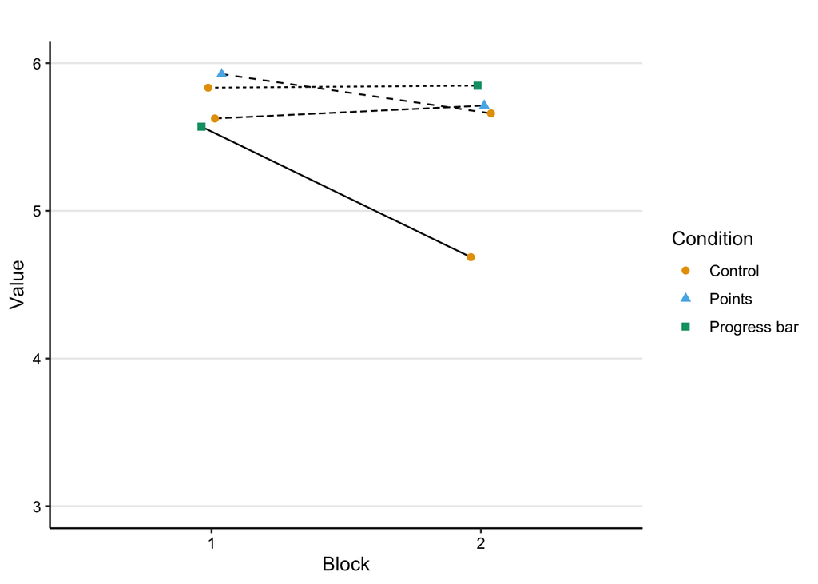

```r
p_value_m
```

## Conclusion

- All three aspects of task motivation (experienced competence, enjoyment, task value) were rated higher in the gamified conditions than in the control condition, but not significantly different between the points and progress bar condition.
- There was also an indirect effect of the manipulation in that the control condition was rated lower when presented after gamified practice than before gamified practice: both enjoyment and perceived task value were significantly worse if the control condition was presented after the gamified condition, and this effect was more pronounced when the control condition was done after the progress bar condition than after the points condition.

# Does gamification change goal setting behavior?

Relevant variables: goal use and wanting to perform well.

## Combined plot

```
`geom_line()`: Each group consists of only one observation.
ℹ Do you need to adjust the group aesthetic?
```

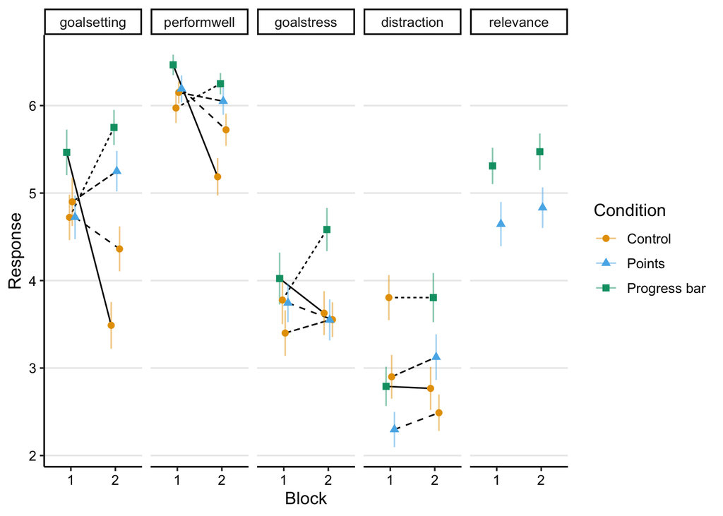

```r
dodge_width <- .25

p_perception <- d_survey_agg |>
  filter(category == "perception") |>
  mutate(question_sorted = factor(question, levels = c("goalsetting","performwell","goalstress","distraction","relevance")))|>
  ggplot(aes(x = block, y = response_mean, group = interaction(exp_order, question))) +
  facet_grid(~ perception_label_sorted, labeller = labeller(question = str_to_title)) +
  geom_line(aes(lty = exp_order), position = position_dodge(width = dodge_width)) +
  geom_errorbar(aes(ymin = response_mean - response_se, ymax = response_mean + response_se, colour = condition),
                width = 0,
                alpha = .5,
                position = position_dodge(width = dodge_width)) +
  geom_point(aes(colour = condition, pch = condition),
             size = 2,
             position = position_dodge(width = dodge_width)) +
  scale_y_continuous(breaks = 1:7) +
  scale_colour_manual(values = col_condition) +
  guides(lty = "none") +
  labs(x = "Block",
       y = "Response",
       colour = "Condition",
       pch = "Condition") +
  theme_paper

p_perception
```

```r
ggsave(p_perception, file = here("output", "survey_perception.png"), width = 8, height = 3)
```

```
`geom_line()`: Each group consists of only one observation.
ℹ Do you need to adjust the group aesthetic?
```

## Goalsetting

### Fit model

```r
m_goalsetting <- lmer(response ~ gamified +
                    gamified:exp_group_c +
                    gamified:gamified_first_c +
                    gamified:gamified_first_c:exp_group_c +
                    (1 | subject),
                  data = filter(d_survey_m, question == "goalsetting"))

summary(m_goalsetting)
```

```
Linear mixed model fit by REML. t-tests use Satterthwaite's method [
lmerModLmerTest]
Formula:
response ~ gamified + gamified:exp_group_c + gamified:gamified_first_c +
    gamified:gamified_first_c:exp_group_c + (1 | subject)
   Data: filter(d_survey_m, question == "goalsetting")

REML criterion at convergence: 1230.9

Scaled residuals:
     Min       1Q   Median       3Q      Max
-2.50358 -0.46869  0.09304  0.60013  2.16834

Random effects:
 Groups   Name        Variance Std.Dev.
 subject  (Intercept) 1.225    1.107
 Residual             1.456    1.207
Number of obs: 332, groups:  subject, 166

Fixed effects:
                                           Estimate Std. Error       df t value
(Intercept)                                  4.3441     0.1271 268.0605  34.180
gamifiedTRUE                                 0.9207     0.1325 162.0000   6.951
gamifiedFALSE:exp_group_c                   -0.5549     0.2545 268.0605  -2.180
gamifiedTRUE:exp_group_c                     0.6310     0.2545 268.0605   2.480
gamifiedFALSE:gamified_first_c              -0.8693     0.2551 268.0605  -3.408
gamifiedTRUE:gamified_first_c               -0.4116     0.2551 268.0605  -1.613
gamifiedFALSE:exp_group_c:gamified_first_c  -0.6956     0.5108 268.0605  -1.362
gamifiedTRUE:exp_group_c:gamified_first_c    0.2417     0.5108 268.0605   0.473
                                           Pr(>|t|)
(Intercept)                                 < 2e-16 ***
gamifiedTRUE                               8.44e-11 ***
gamifiedFALSE:exp_group_c                  0.030097 *
gamifiedTRUE:exp_group_c                   0.013764 *
gamifiedFALSE:gamified_first_c             0.000756 ***
gamifiedTRUE:gamified_first_c              0.107846
gamifiedFALSE:exp_group_c:gamified_first_c 0.174446
gamifiedTRUE:exp_group_c:gamified_first_c  0.636460
---
Signif. codes:  0 '***' 0.001 '**' 0.01 '*' 0.05 '.' 0.1 ' ' 1

Correlation of Fixed Effects:
              (Intr) gmTRUE gmfdFALSE:x__ gmfdTRUE:x__ gmfdFALSE:g__
gamifidTRUE   -0.521
gmfdFALSE:x__  0.000  0.000
gmfdTRUE:x__   0.000  0.000  0.457
gmfdFALSE:g__  0.000  0.000 -0.004        -0.002
gmfdTRUE:g__   0.000  0.000 -0.002        -0.004        0.457
gFALSE:__:_   -0.004  0.002  0.000         0.000        0.001
gTRUE:__:__   -0.002 -0.002  0.000         0.000        0.000
              gmfdTRUE:g__ gFALSE:__:
gamifidTRUE
gmfdFALSE:x__
gmfdTRUE:x__
gmfdFALSE:g__
gmfdTRUE:g__
gFALSE:__:_    0.000
gTRUE:__:__    0.001        0.457
```

```r
print_model_table(m_goalsetting)
```

| Effect | Estimate | SE | df | t-value | p-value |
| --- | --- | --- | --- | --- | --- |
| Intercept (Control) | 4.344 | 0.127 | 268.06 | 34.18 | <.001 |
| Gamification | 0.921 | 0.132 | 162.00 | 6.95 | <.001 |
| Type of gamification (Progress bar - Points) | 0.631 | 0.254 | 268.06 | 2.48 | .014 |
| Type of gamification on Control (Progress bar - Points) | -0.555 | 0.254 | 268.06 | -2.18 | .030 |
| Block on gamification (1 - 2) | -0.412 | 0.255 | 268.06 | -1.61 | .108 |
| Block on Control (2 - 1) | -0.869 | 0.255 | 268.06 | -3.41 | .001 |
| Type of gamification; block difference (Block 1 - Block 2) | 0.242 | 0.511 | 268.06 | 0.47 | .636 |
| Type of gamification on Control; block difference (Block 2 - Block 1) | -0.696 | 0.511 | 268.06 | -1.36 | .174 |

### Fitted values

Gamified versus control:

```r
d_model_fit <- crossing(
  gamified = sort(unique(d_survey_m$gamified)),
  exp_group_c = 0,
  gamified_first_c = 0
)

d_model_fit$model_fit <- predict(m_goalsetting,
                                 newdata = d_model_fit,
                                 re.form = NA,
                                 type = "response")

d_model_fit
```

| gamified | exp_group_c | gamified_first_c | model_fit |
| --- | --- | --- | --- |
| FALSE | 0 | 0 | 4.344080 |
| TRUE | 0 | 0 | 5.264815 |

Points group versus progress bar group:

```r
d_model_fit <- crossing(
  gamified = TRUE,
  exp_group_c = sort(unique(d_survey_m$exp_group_c)),
  gamified_first_c = 0
)

d_model_fit$model_fit <- predict(m_goalsetting,
                                 newdata = d_model_fit,
                                 re.form = NA,
                                 type = "response")

d_model_fit
```

| gamified | exp_group_c | gamified_first_c | model_fit |
| --- | --- | --- | --- |
| TRUE | -0.4759036 | 0 | 4.964496 |
| TRUE | 0.5240964 | 0 | 5.595545 |

Control condition: gamified first vs. gamified second:

```r
d_model_fit <- crossing(
  gamified = FALSE,
  exp_group_c = 0,
  gamified_first_c = sort(unique(d_survey_m$gamified_first_c))
)

d_model_fit$model_fit <- predict(m_goalsetting,
                                 newdata = d_model_fit,
                                 re.form = NA,
                                 type = "response")

d_model_fit
```

| gamified | exp_group_c | gamified_first_c | model_fit |
| --- | --- | --- | --- |
| FALSE | 0 | -0.5421687 | 4.815395 |
| FALSE | 0 | 0.4578313 | 3.946081 |

Control condition: progress bar group vs. points group:

```r
d_model_fit <- crossing(
  gamified = FALSE,
  exp_group_c = sort(unique(d_survey_m$exp_group_c)),
  gamified_first_c = 0
)

d_model_fit$model_fit <- predict(m_goalsetting,
                                 newdata = d_model_fit,
                                 re.form = NA,
                                 type = "response")

d_model_fit
```

| gamified | exp_group_c | gamified_first_c | model_fit |
| --- | --- | --- | --- |
| FALSE | -0.4759036 | 0 | 4.608152 |
| FALSE | 0.5240964 | 0 | 4.053267 |

### Visualise fitted model

```r
p_goalsetting_m <- plot_model_fit(m_goalsetting, filter(d_survey_m, question == "goalsetting"), y_lab = "Goal use") +
  scale_y_continuous(limits = c(3, 6), labels = scales::comma_format())
```

```
  block    condition gamified gamified_first exp_group gamified_first_c
1     1      Control    FALSE          FALSE      both       -0.5421687
2     1      Control    FALSE          FALSE     score       -0.5421687
3     1       Points     TRUE           TRUE     score        0.4578313
4     1 Progress bar     TRUE           TRUE      both        0.4578313
5     2      Control    FALSE           TRUE      both        0.4578313
6     2      Control    FALSE           TRUE     score        0.4578313
7     2       Points     TRUE          FALSE     score       -0.5421687
8     2 Progress bar     TRUE          FALSE      both       -0.5421687
  exp_group_c pred_val     exp_order     type
1   0.5240964 4.722222  Control—Both  Control
2  -0.4759036 4.900000 Control—Score  Control
3  -0.4759036 4.723404 Score—Control Gamified
4   0.5240964 5.465116  Both—Control Gamified
5   0.5240964 3.488372  Both—Control  Control
6  -0.4759036 4.361702 Score—Control  Control
7  -0.4759036 5.250000 Control—Score Gamified
8   0.5240964 5.750000  Control—Both Gamified
```

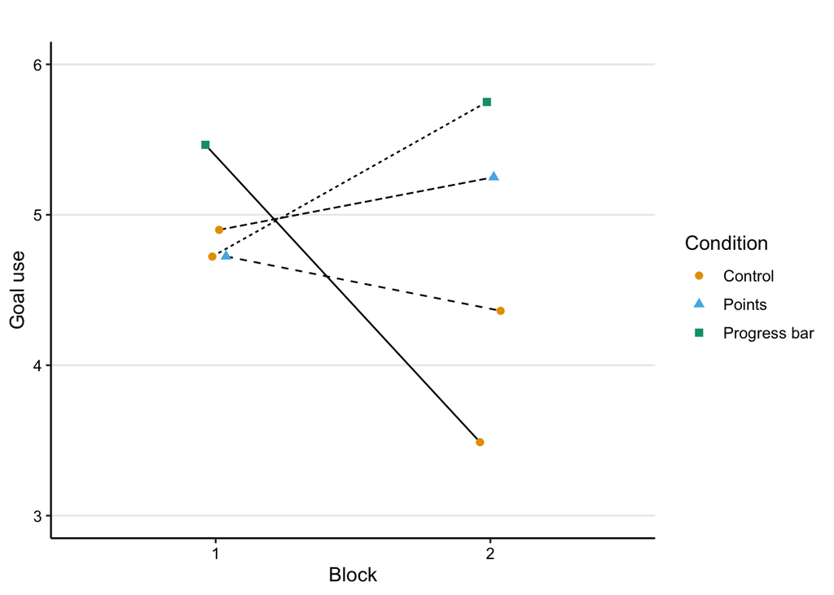

```r
p_goalsetting_m
```

## Wanting to perform well

### Fit model

```r
m_performwell <- lmer(response ~ gamified +
                        gamified:exp_group_c +
                        gamified:gamified_first_c +
                        gamified:gamified_first_c:exp_group_c +
                        (1 | subject),
                      data = filter(d_survey_m, question == "performwell"))

summary(m_performwell)
```

```
Linear mixed model fit by REML. t-tests use Satterthwaite's method [
lmerModLmerTest]
Formula:
response ~ gamified + gamified:exp_group_c + gamified:gamified_first_c +
    gamified:gamified_first_c:exp_group_c + (1 | subject)
   Data: filter(d_survey_m, question == "performwell")

REML criterion at convergence: 930.6

Scaled residuals:
    Min      1Q  Median      3Q     Max
-3.0045 -0.3379  0.1355  0.5652  1.6591

Random effects:
 Groups   Name        Variance Std.Dev.
 subject  (Intercept) 0.5291   0.7274
 Residual             0.5530   0.7436
Number of obs: 332, groups:  subject, 166

Fixed effects:
                                            Estimate Std. Error        df
(Intercept)                                  5.74133    0.08074 261.48308
gamifiedTRUE                                 0.49956    0.08163 162.00000
gamifiedFALSE:exp_group_c                   -0.37273    0.16167 261.48308
gamifiedTRUE:exp_group_c                     0.23992    0.16167 261.48308
gamifiedFALSE:gamified_first_c              -0.59772    0.16206 261.48308
gamifiedTRUE:gamified_first_c                0.17653    0.16206 261.48308
gamifiedFALSE:exp_group_c:gamified_first_c  -0.35958    0.32450 261.48308
gamifiedTRUE:exp_group_c:gamified_first_c    0.07363    0.32450 261.48308
                                           t value Pr(>|t|)
(Intercept)                                 71.109  < 2e-16 ***
gamifiedTRUE                                 6.120 6.79e-09 ***
gamifiedFALSE:exp_group_c                   -2.306 0.021920 *
gamifiedTRUE:exp_group_c                     1.484 0.139010
gamifiedFALSE:gamified_first_c              -3.688 0.000275 ***
gamifiedTRUE:gamified_first_c                1.089 0.277028
gamifiedFALSE:exp_group_c:gamified_first_c  -1.108 0.268841
gamifiedTRUE:exp_group_c:gamified_first_c    0.227 0.820686
---
Signif. codes:  0 '***' 0.001 '**' 0.01 '*' 0.05 '.' 0.1 ' ' 1

Correlation of Fixed Effects:
              (Intr) gmTRUE gmfdFALSE:x__ gmfdTRUE:x__ gmfdFALSE:g__
gamifidTRUE   -0.505
gmfdFALSE:x__  0.000  0.000
gmfdTRUE:x__   0.000  0.000  0.489
gmfdFALSE:g__  0.000  0.000 -0.004        -0.002
gmfdTRUE:g__   0.000  0.000 -0.002        -0.004        0.489
gFALSE:__:_   -0.004  0.002  0.000         0.000        0.001
gTRUE:__:__   -0.002 -0.002  0.000         0.000        0.000
              gmfdTRUE:g__ gFALSE:__:
gamifidTRUE
gmfdFALSE:x__
gmfdTRUE:x__
gmfdFALSE:g__
gmfdTRUE:g__
gFALSE:__:_    0.000
gTRUE:__:__    0.001        0.489
```

```r
print_model_table(m_performwell)
```

| Effect | Estimate | SE | df | t-value | p-value |
| --- | --- | --- | --- | --- | --- |
| Intercept (Control) | 5.741 | 0.081 | 261.48 | 71.11 | <.001 |
| Gamification | 0.500 | 0.082 | 162.00 | 6.12 | <.001 |
| Type of gamification (Progress bar - Points) | 0.240 | 0.162 | 261.48 | 1.48 | .139 |
| Type of gamification on Control (Progress bar - Points) | -0.373 | 0.162 | 261.48 | -2.31 | .022 |
| Block on gamification (1 - 2) | 0.177 | 0.162 | 261.48 | 1.09 | .277 |
| Block on Control (2 - 1) | -0.598 | 0.162 | 261.48 | -3.69 | <.001 |
| Type of gamification; block difference (Block 1 - Block 2) | 0.074 | 0.325 | 261.48 | 0.23 | .821 |
| Type of gamification on Control; block difference (Block 2 - Block 1) | -0.360 | 0.325 | 261.48 | -1.11 | .269 |

### Fitted values

Gamified versus control:

```r
d_model_fit <- crossing(
  gamified = sort(unique(d_survey_m$gamified)),
  exp_group_c = 0,
  gamified_first_c = 0
)

d_model_fit$model_fit <- predict(m_performwell,
                                 newdata = d_model_fit,
                                 re.form = NA,
                                 type = "response")

d_model_fit
```

| gamified | exp_group_c | gamified_first_c | model_fit |
| --- | --- | --- | --- |
| FALSE | 0 | 0 | 5.741329 |
| TRUE | 0 | 0 | 6.240889 |

Points group versus progress bar group:

```r
d_model_fit <- crossing(
  gamified = TRUE,
  exp_group_c = sort(unique(d_survey_m$exp_group_c)),
  gamified_first_c = 0
)

d_model_fit$model_fit <- predict(m_performwell,
                                 newdata = d_model_fit,
                                 re.form = NA,
                                 type = "response")

d_model_fit
```

| gamified | exp_group_c | gamified_first_c | model_fit |
| --- | --- | --- | --- |
| TRUE | -0.4759036 | 0 | 6.126711 |
| TRUE | 0.5240964 | 0 | 6.366629 |

Control condition: gamified first vs. gamified second:

```r
d_model_fit <- crossing(
  gamified = FALSE,
  exp_group_c = 0,
  gamified_first_c = sort(unique(d_survey_m$gamified_first_c))
)

d_model_fit$model_fit <- predict(m_performwell,
                                 newdata = d_model_fit,
                                 re.form = NA,
                                 type = "response")

d_model_fit
```

| gamified | exp_group_c | gamified_first_c | model_fit |
| --- | --- | --- | --- |
| FALSE | 0 | -0.5421687 | 6.065395 |
| FALSE | 0 | 0.4578313 | 5.467674 |

Control condition in progress bar group vs. points group:

```r
d_model_fit <- crossing(
  gamified = FALSE,
  exp_group_c = sort(unique(d_survey_m$exp_group_c)),
  gamified_first_c = 0
)

d_model_fit$model_fit <- predict(m_performwell,
                                 newdata = d_model_fit,
                                 re.form = NA,
                                 type = "response")

d_model_fit
```

| gamified | exp_group_c | gamified_first_c | model_fit |
| --- | --- | --- | --- |
| FALSE | -0.4759036 | 0 | 5.918713 |
| FALSE | 0.5240964 | 0 | 5.545982 |

### Visualise fitted model

```r
p_performwell_m <- plot_model_fit(m_performwell, filter(d_survey_m, question == "performwell"), y_lab = "Wanting to perform well") +
  scale_y_continuous(limits = c(4, 7), labels = scales::comma_format())
```

```
  block    condition gamified gamified_first exp_group gamified_first_c
1     1      Control    FALSE          FALSE      both       -0.5421687
2     1      Control    FALSE          FALSE     score       -0.5421687
3     1       Points     TRUE           TRUE     score        0.4578313
4     1 Progress bar     TRUE           TRUE      both        0.4578313
5     2      Control    FALSE           TRUE      both        0.4578313
6     2      Control    FALSE           TRUE     score        0.4578313
7     2       Points     TRUE          FALSE     score       -0.5421687
8     2 Progress bar     TRUE          FALSE      both       -0.5421687
  exp_group_c pred_val     exp_order     type
1   0.5240964 5.972222  Control—Both  Control
2  -0.4759036 6.150000 Control—Score  Control
3  -0.4759036 6.191489 Score—Control Gamified
4   0.5240964 6.465116  Both—Control Gamified
5   0.5240964 5.186047  Both—Control  Control
6  -0.4759036 5.723404 Score—Control  Control
7  -0.4759036 6.050000 Control—Score Gamified
8   0.5240964 6.250000  Control—Both Gamified
```

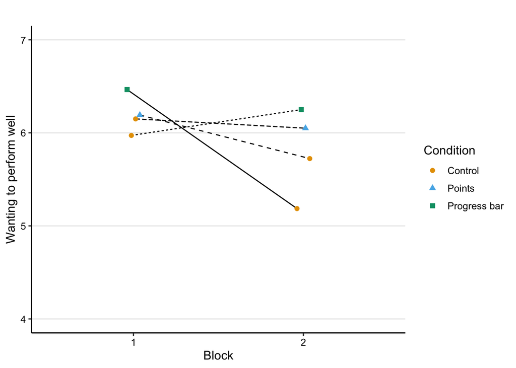

```r
p_performwell_m
```

## Conclusion

- The two aspects of goal setting (feeling like working towards a goal, trying to perform well) were rated higher in the gamified conditions than the control condition
- Learners felt more like they were working towards a goal with progress bar feedback than with points.
- There were also indirect effects: Learners felt less like working towards a goal and tried less to perform well in the control condition when they had started with gamified practice and/or when in the progress bar group

# Are there negative effects of gamified feedback on learners’ experience?

Relevant variables: stress and distraction.

## Stress

```r
m_goalstress <- lmer(response ~ gamified +
                       gamified:exp_group_c +
                       gamified:gamified_first_c +
                       gamified:gamified_first_c:exp_group_c +
                       (1 | subject),
                     data = filter(d_survey_m, question == "goalstress"))

summary(m_goalstress)
```

```
Linear mixed model fit by REML. t-tests use Satterthwaite's method [
lmerModLmerTest]
Formula:
response ~ gamified + gamified:exp_group_c + gamified:gamified_first_c +
    gamified:gamified_first_c:exp_group_c + (1 | subject)
   Data: filter(d_survey_m, question == "goalstress")

REML criterion at convergence: 1186.3

Scaled residuals:
     Min       1Q   Median       3Q      Max
-1.84686 -0.53139 -0.03832  0.52102  1.93172

Random effects:
 Groups   Name        Variance Std.Dev.
 subject  (Intercept) 1.487    1.219
 Residual             1.069    1.034
Number of obs: 332, groups:  subject, 166

Fixed effects:
                                             Estimate Std. Error         df
(Intercept)                                  3.584645   0.124081 242.064754
gamifiedTRUE                                 0.367929   0.113479 162.000003
gamifiedFALSE:exp_group_c                    0.213467   0.248451 242.064754
gamifiedTRUE:exp_group_c                     0.624127   0.248451 242.064754
gamifiedFALSE:gamified_first_c               0.008963   0.249049 242.064754
gamifiedTRUE:gamified_first_c               -0.164511   0.249049 242.064754
gamifiedFALSE:exp_group_c:gamified_first_c  -0.303062   0.498695 242.064754
gamifiedTRUE:exp_group_c:gamified_first_c   -0.754758   0.498695 242.064754
                                           t value Pr(>|t|)
(Intercept)                                 28.890  < 2e-16 ***
gamifiedTRUE                                 3.242  0.00144 **
gamifiedFALSE:exp_group_c                    0.859  0.39108
gamifiedTRUE:exp_group_c                     2.512  0.01265 *
gamifiedFALSE:gamified_first_c               0.036  0.97132
gamifiedTRUE:gamified_first_c               -0.661  0.50952
gamifiedFALSE:exp_group_c:gamified_first_c  -0.608  0.54395
gamifiedTRUE:exp_group_c:gamified_first_c   -1.513  0.13147
---
Signif. codes:  0 '***' 0.001 '**' 0.01 '*' 0.05 '.' 0.1 ' ' 1

Correlation of Fixed Effects:
              (Intr) gmTRUE gmfdFALSE:x__ gmfdTRUE:x__ gmfdFALSE:g__
gamifidTRUE   -0.457
gmfdFALSE:x__  0.000  0.000
gmfdTRUE:x__   0.000  0.000  0.582
gmfdFALSE:g__  0.000  0.000 -0.004        -0.002
gmfdTRUE:g__   0.000  0.000 -0.002        -0.004        0.582
gFALSE:__:_   -0.004  0.002  0.000         0.000        0.001
gTRUE:__:__   -0.002 -0.002  0.000         0.000        0.000
              gmfdTRUE:g__ gFALSE:__:
gamifidTRUE
gmfdFALSE:x__
gmfdTRUE:x__
gmfdFALSE:g__
gmfdTRUE:g__
gFALSE:__:_    0.000
gTRUE:__:__    0.001        0.582
```

```r
print_model_table(m_goalstress)
```

| Effect | Estimate | SE | df | t-value | p-value |
| --- | --- | --- | --- | --- | --- |
| Intercept (Control) | 3.585 | 0.124 | 242.06 | 28.89 | <.001 |
| Gamification | 0.368 | 0.113 | 162.00 | 3.24 | .001 |
| Type of gamification (Progress bar - Points) | 0.624 | 0.248 | 242.06 | 2.51 | .013 |
| Type of gamification on Control (Progress bar - Points) | 0.213 | 0.248 | 242.06 | 0.86 | .391 |
| Block on gamification (1 - 2) | -0.165 | 0.249 | 242.06 | -0.66 | .510 |
| Block on Control (2 - 1) | 0.009 | 0.249 | 242.06 | 0.04 | .971 |
| Type of gamification; block difference (Block 1 - Block 2) | -0.755 | 0.499 | 242.06 | -1.51 | .131 |
| Type of gamification on Control; block difference (Block 2 - Block 1) | -0.303 | 0.499 | 242.06 | -0.61 | .544 |

### Fitted values

Gamified versus control:

```r
d_model_fit <- crossing(
  gamified = sort(unique(d_survey_m$gamified)),
  exp_group_c = 0,
  gamified_first_c = 0
)

d_model_fit$model_fit <- predict(m_goalstress,
                                 newdata = d_model_fit,
                                 re.form = NA,
                                 type = "response")

d_model_fit
```

| gamified | exp_group_c | gamified_first_c | model_fit |
| --- | --- | --- | --- |
| FALSE | 0 | 0 | 3.584645 |
| TRUE | 0 | 0 | 3.952574 |

Points group versus progress bar group:

```r
d_model_fit <- crossing(
  gamified = TRUE,
  exp_group_c = sort(unique(d_survey_m$exp_group_c)),
  gamified_first_c = 0
)

d_model_fit$model_fit <- predict(m_goalstress,
                                 newdata = d_model_fit,
                                 re.form = NA,
                                 type = "response")

d_model_fit
```

| gamified | exp_group_c | gamified_first_c | model_fit |
| --- | --- | --- | --- |
| TRUE | -0.4759036 | 0 | 3.655550 |
| TRUE | 0.5240964 | 0 | 4.279677 |

### Visualise fitted model

```r
p_goalstress_m <- plot_model_fit(m_goalstress, filter(d_survey_m, question == "goalstress"), y_lab = "Goal stress") +
  scale_y_continuous(limits = c(3, 6), labels = scales::comma_format())
```

```
  block    condition gamified gamified_first exp_group gamified_first_c
1     1      Control    FALSE          FALSE      both       -0.5421687
2     1      Control    FALSE          FALSE     score       -0.5421687
3     1       Points     TRUE           TRUE     score        0.4578313
4     1 Progress bar     TRUE           TRUE      both        0.4578313
5     2      Control    FALSE           TRUE      both        0.4578313
6     2      Control    FALSE           TRUE     score        0.4578313
7     2       Points     TRUE          FALSE     score       -0.5421687
8     2 Progress bar     TRUE          FALSE      both       -0.5421687
  exp_group_c pred_val     exp_order     type
1   0.5240964 3.777778  Control—Both  Control
2  -0.4759036 3.400000 Control—Score  Control
3  -0.4759036 3.744681 Score—Control Gamified
4   0.5240964 4.023256  Both—Control Gamified
5   0.5240964 3.627907  Both—Control  Control
6  -0.4759036 3.553191 Score—Control  Control
7  -0.4759036 3.550000 Control—Score Gamified
8   0.5240964 4.583333  Control—Both Gamified
```

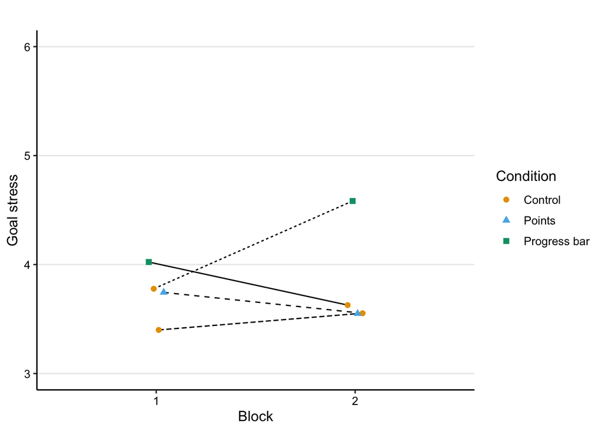

```r
p_goalstress_m
```

## Distraction

```r
m_distraction <- lmer(response ~ gamified +
                       gamified:exp_group_c +
                       gamified:gamified_first_c +
                       gamified:gamified_first_c:exp_group_c +
                       (1 | subject),
                     data = filter(d_survey_m, question == "distraction"))

summary(m_distraction)
```

```
Linear mixed model fit by REML. t-tests use Satterthwaite's method [
lmerModLmerTest]
Formula:
response ~ gamified + gamified:exp_group_c + gamified:gamified_first_c +
    gamified:gamified_first_c:exp_group_c + (1 | subject)
   Data: filter(d_survey_m, question == "distraction")

REML criterion at convergence: 1216.2

Scaled residuals:
    Min      1Q  Median      3Q     Max
-2.0444 -0.6717 -0.1767  0.4219  2.8290

Random effects:
 Groups   Name        Variance Std.Dev.
 subject  (Intercept) 0.6679   0.8172
 Residual             1.7075   1.3067
Number of obs: 332, groups:  subject, 166

Fixed effects:
                                             Estimate Std. Error         df
(Intercept)                                  2.946421   0.119623 300.263104
gamifiedTRUE                                 0.005577   0.143431 161.999985
gamifiedFALSE:exp_group_c                    0.565358   0.239524 300.263104
gamifiedTRUE:exp_group_c                     0.578774   0.239524 300.263104
gamifiedFALSE:gamified_first_c              -0.709256   0.240101 300.263104
gamifiedTRUE:gamified_first_c               -0.916469   0.240101 300.263104
gamifiedFALSE:exp_group_c:gamified_first_c  -0.627475   0.480778 300.263104
gamifiedTRUE:exp_group_c:gamified_first_c   -0.187730   0.480778 300.263104
                                           t value Pr(>|t|)
(Intercept)                                 24.631  < 2e-16 ***
gamifiedTRUE                                 0.039 0.969030
gamifiedFALSE:exp_group_c                    2.360 0.018898 *
gamifiedTRUE:exp_group_c                     2.416 0.016273 *
gamifiedFALSE:gamified_first_c              -2.954 0.003385 **
gamifiedTRUE:gamified_first_c               -3.817 0.000164 ***
gamifiedFALSE:exp_group_c:gamified_first_c  -1.305 0.192849
gamifiedTRUE:exp_group_c:gamified_first_c   -0.390 0.696464
---
Signif. codes:  0 '***' 0.001 '**' 0.01 '*' 0.05 '.' 0.1 ' ' 1

Correlation of Fixed Effects:
              (Intr) gmTRUE gmfdFALSE:x__ gmfdTRUE:x__ gmfdFALSE:g__
gamifidTRUE   -0.600
gmfdFALSE:x__  0.000  0.000
gmfdTRUE:x__   0.000  0.000  0.281
gmfdFALSE:g__  0.000  0.000 -0.004        -0.001
gmfdTRUE:g__   0.000  0.000 -0.001        -0.004        0.281
gFALSE:__:_   -0.004  0.002  0.000         0.000        0.001
gTRUE:__:__   -0.001 -0.002  0.000         0.000        0.000
              gmfdTRUE:g__ gFALSE:__:
gamifidTRUE
gmfdFALSE:x__
gmfdTRUE:x__
gmfdFALSE:g__
gmfdTRUE:g__
gFALSE:__:_    0.000
gTRUE:__:__    0.001        0.281
```

```r
print_model_table(m_distraction)
```

| Effect | Estimate | SE | df | t-value | p-value |
| --- | --- | --- | --- | --- | --- |
| Intercept (Control) | 2.946 | 0.120 | 300.26 | 24.63 | <.001 |
| Gamification | 0.006 | 0.143 | 162.00 | 0.04 | .969 |
| Type of gamification (Progress bar - Points) | 0.579 | 0.240 | 300.26 | 2.42 | .016 |
| Type of gamification on Control (Progress bar - Points) | 0.565 | 0.240 | 300.26 | 2.36 | .019 |
| Block on gamification (1 - 2) | -0.916 | 0.240 | 300.26 | -3.82 | <.001 |
| Block on Control (2 - 1) | -0.709 | 0.240 | 300.26 | -2.95 | .003 |
| Type of gamification; block difference (Block 1 - Block 2) | -0.188 | 0.481 | 300.26 | -0.39 | .696 |
| Type of gamification on Control; block difference (Block 2 - Block 1) | -0.627 | 0.481 | 300.26 | -1.31 | .193 |

### Fitted values

Points versus progress bar condition

```r
d_model_fit <- crossing(
  gamified = TRUE,
  exp_group_c = sort(unique(d_survey_m$exp_group_c)),
  gamified_first_c = 0
)

d_model_fit$model_fit <- predict(m_distraction,
                                 newdata = d_model_fit,
                                 re.form = NA,
                                 type = "response")

d_model_fit
```

| gamified | exp_group_c | gamified_first_c | model_fit |
| --- | --- | --- | --- |
| TRUE | -0.4759036 | 0 | 2.676557 |
| TRUE | 0.5240964 | 0 | 3.255331 |

Control condition in Block 1 versus Block 2

```r
d_model_fit <- crossing(
  gamified = FALSE,
  exp_group_c = 0,
  gamified_first_c = sort(unique(d_survey_m$exp_group_c))
)

d_model_fit$model_fit <- predict(m_distraction,
                                 newdata = d_model_fit,
                                 re.form = NA,
                                 type = "response")

d_model_fit
```

| gamified | exp_group_c | gamified_first_c | model_fit |
| --- | --- | --- | --- |
| FALSE | 0 | -0.4759036 | 3.283958 |
| FALSE | 0 | 0.5240964 | 2.574702 |

Gamified conditions in Block 1 versus Block 2

```r
d_model_fit <- crossing(
  gamified = TRUE,
  exp_group_c = 0,
  gamified_first_c = sort(unique(d_survey_m$gamified_first_c))
)

d_model_fit$model_fit <- predict(m_distraction,
                                 newdata = d_model_fit,
                                 re.form = NA,
                                 type = "response")

d_model_fit
```

| gamified | exp_group_c | gamified_first_c | model_fit |
| --- | --- | --- | --- |
| TRUE | 0 | -0.5421687 | 3.448879 |
| TRUE | 0 | 0.4578313 | 2.532410 |

### Visualise fitted model

```r
p_distraction_m <- plot_model_fit(m_distraction, filter(d_survey_m, question == "distraction"), y_lab = "Distraction") +
  scale_y_continuous(limits = c(1.5, 4.5), labels = scales::comma_format())
```

```
  block    condition gamified gamified_first exp_group gamified_first_c
1     1      Control    FALSE          FALSE      both       -0.5421687
2     1      Control    FALSE          FALSE     score       -0.5421687
3     1       Points     TRUE           TRUE     score        0.4578313
4     1 Progress bar     TRUE           TRUE      both        0.4578313
5     2      Control    FALSE           TRUE      both        0.4578313
6     2      Control    FALSE           TRUE     score        0.4578313
7     2       Points     TRUE          FALSE     score       -0.5421687
8     2 Progress bar     TRUE          FALSE      both       -0.5421687
  exp_group_c pred_val     exp_order     type
1   0.5240964 3.805556  Control—Both  Control
2  -0.4759036 2.900000 Control—Score  Control
3  -0.4759036 2.297872 Score—Control Gamified
4   0.5240964 2.790698  Both—Control Gamified
5   0.5240964 2.767442  Both—Control  Control
6  -0.4759036 2.489362 Score—Control  Control
7  -0.4759036 3.125000 Control—Score Gamified
8   0.5240964 3.805556  Control—Both Gamified
```

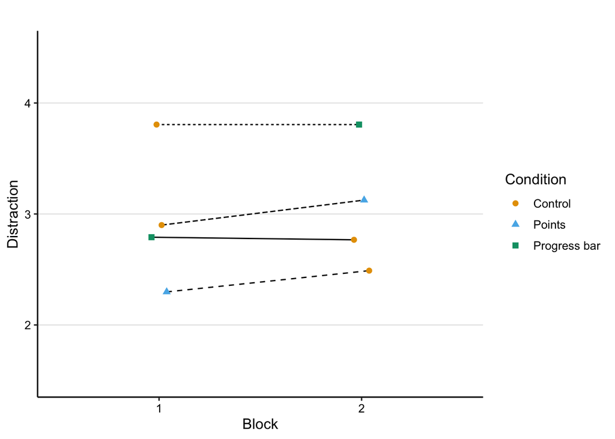

```r
p_distraction_m
```

## Conclusion

- Gamified practice was rated as more stressful than the control condition
- The progress bar condition was rated as more stressful and more distracting than the points condition. (However, ratings were overall relatively low on the 7-point scale, with average values between 2.68 and 4.28).
- There was also an indirect effect in that the gamified feedback was rated as more distracting (and the timer in the control condition as less distracting) when presented in the second block.

# Which Condition do Learners prefer?

Relevant variables: perceived relevance of gamification, preference for condition.

## Perceived Relevance

Since perceived relevance was only rated in the gamified conditions, we cannot use the same model as elsewhere. Instead we can use a simpler linear regression:

```r
m_relevance <- lm(response ~ exp_group_c +
                    gamified_first_c +
                    gamified_first_c:exp_group_c,
                  data = filter(d_survey_m, question == "relevance", gamified == TRUE))

summary(m_relevance)
```

```
Call:
lm(formula = response ~ exp_group_c + gamified_first_c + gamified_first_c:exp_group_c,
    data = filter(d_survey_m, question == "relevance", gamified ==
        TRUE))

Residuals:
    Min      1Q  Median      3Q     Max
-4.3101 -0.9782  0.3546  1.0233  2.3546

Coefficients:
                             Estimate Std. Error t value Pr(>|t|)
(Intercept)                    5.0421     0.1148  43.916  < 2e-16 ***
exp_group_c                    0.6529     0.2299   2.840  0.00509 **
gamified_first_c              -0.1757     0.2304  -0.762  0.44700
exp_group_c:gamified_first_c   0.0258     0.4614   0.056  0.95548
---
Signif. codes:  0 '***' 0.001 '**' 0.01 '*' 0.05 '.' 0.1 ' ' 1

Residual standard error: 1.479 on 162 degrees of freedom
Multiple R-squared:  0.05059,   Adjusted R-squared:  0.03301
F-statistic: 2.877 on 3 and 162 DF,  p-value: 0.03782
```

### Fitted values

```r
d_model_fit <- crossing(
  exp_group_c = sort(unique(d_survey_m$exp_group_c)),
  gamified_first_c = 0,
)

d_model_fit$model_fit <- predict(m_relevance,
                                 newdata = d_model_fit,
                                 re.form = NA,
                                 type = "response")

d_model_fit
```

| exp_group_c | gamified_first_c | model_fit |
| --- | --- | --- |
| -0.4759036 | 0 | 4.731436 |
| 0.5240964 | 0 | 5.384312 |

## Preference for Condition

```r
data_preferences <- d_survey |> filter(preference!="" & condition != "Control") # Exclude two participants who did not respond to this item and keep only one row per participant
CrossTable_preferences <-  table(data_preferences$exp_group, data_preferences$preference)
CrossTable_preferences
```

```
        Control Experimental NoPreference
  both      128          432           56
  score     176          408          112
```

```r
prop.table(CrossTable_preferences,1)
```

```
           Control Experimental NoPreference
  both  0.20779221   0.70129870   0.09090909
  score 0.25287356   0.58620690   0.16091954
```

```r
summary(table(data_preferences$exp_group, data_preferences$preference))
```

```
Number of cases in table: 1312
Number of factors: 2
Test for independence of all factors:
    Chisq = 22.136, df = 2, p-value = 1.561e-05
```

## Conclusions

# Does gamification change learners’ metacognitive judgements?

Relevant variable: judgement of learning.

## Judgement of learning

Participants were asked to give the percentage of practiced translations they thought they would still know in two days.

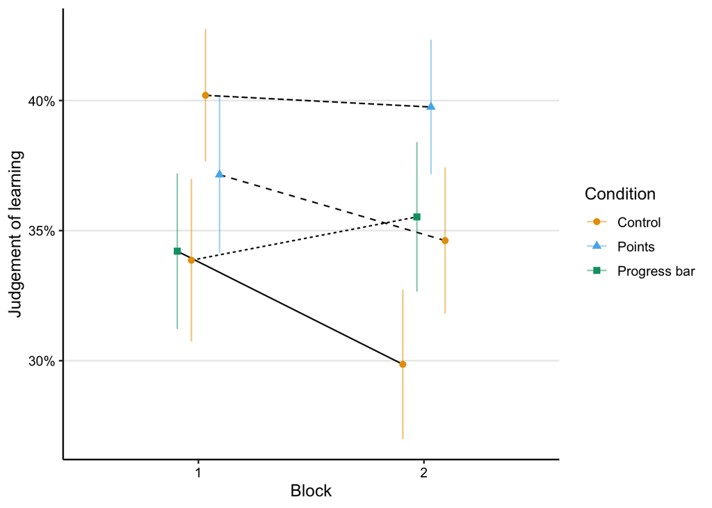

```r
d_jol_agg <- d_survey |>
  group_by(subject, block, condition, gamified, gamified_first, exp_group) |>
  summarise(judgement_of_learning = judgement_of_learning[1]/100) |>
  group_by(block, condition, gamified, gamified_first, exp_group) |>
  summarise(jol_mean = mean(judgement_of_learning, na.rm = T),
            jol_se = sd(judgement_of_learning, na.rm = T)/sqrt(n())) |>
  ungroup() |>
  add_experiment_cols()
dodge_width <- .25

p_jol <- ggplot(d_jol_agg, aes(x = block, y = jol_mean, group = exp_order)) +
  geom_line(aes(lty = exp_order), position = position_dodge(width = dodge_width)) +
  geom_errorbar(aes(ymin = jol_mean - jol_se, ymax = jol_mean + jol_se, colour = condition),
                width = 0,
                alpha = .5,
                position = position_dodge(width = dodge_width)) +
  geom_point(aes(colour = condition, pch = condition),
             size = 2,
             position = position_dodge(width = dodge_width)) +
  scale_colour_manual(values = col_condition) +
  scale_y_continuous(labels = scales::percent_format()) +
  guides(lty = "none") +
  labs(x = "Block",
       y = "Judgement of learning",
       colour = "Condition",
       pch = "Condition") +
  theme_paper

p_jol
```

```r
ggsave(p_jol, filename = here("output", "survey_judgementoflearning.png"), width = 8, height = 3)
```

### Fit model

```r
d_jol_m <- d_survey_m |>
  group_by(subject, gamified, block, condition, gamified_first, exp_group, gamified_first_c, exp_group_c) |>
  summarise(judgement_of_learning = judgement_of_learning[1]/100) |>
  ungroup()
```

[output not shown]

```r
m_jol <- lmer(judgement_of_learning ~ gamified +
                gamified:exp_group_c +
                gamified:gamified_first_c +
                gamified:gamified_first_c:exp_group_c +
                (1 | subject),
              data = d_jol_m)

summary(m_jol)
```

```
Linear mixed model fit by REML. t-tests use Satterthwaite's method [
lmerModLmerTest]
Formula:
judgement_of_learning ~ gamified + gamified:exp_group_c + gamified:gamified_first_c +
    gamified:gamified_first_c:exp_group_c + (1 | subject)
   Data: d_jol_m

REML criterion at convergence: -287.3

Scaled residuals:
    Min      1Q  Median      3Q     Max
-3.6291 -0.4202 -0.0289  0.4106  3.4697

Random effects:
 Groups   Name        Variance Std.Dev.
 subject  (Intercept) 0.02623  0.1620
 Residual             0.00801  0.0895
Number of obs: 332, groups:  subject, 166

Fixed effects:
                                             Estimate Std. Error         df
(Intercept)                                  0.345647   0.014362 204.178850
gamifiedTRUE                                 0.020967   0.009824 162.000003
gamifiedFALSE:exp_group_c                   -0.054810   0.028757 204.178850
gamifiedTRUE:exp_group_c                    -0.035268   0.028757 204.178850
gamifiedFALSE:gamified_first_c              -0.048299   0.028826 204.178850
gamifiedTRUE:gamified_first_c               -0.019907   0.028826 204.178850
gamifiedFALSE:exp_group_c:gamified_first_c   0.015823   0.057721 204.178850
gamifiedTRUE:exp_group_c:gamified_first_c    0.012826   0.057721 204.178850
                                           t value Pr(>|t|)
(Intercept)                                 24.067   <2e-16 ***
gamifiedTRUE                                 2.134   0.0343 *
gamifiedFALSE:exp_group_c                   -1.906   0.0581 .
gamifiedTRUE:exp_group_c                    -1.226   0.2214
gamifiedFALSE:gamified_first_c              -1.676   0.0954 .
gamifiedTRUE:gamified_first_c               -0.691   0.4906
gamifiedFALSE:exp_group_c:gamified_first_c   0.274   0.7843
gamifiedTRUE:exp_group_c:gamified_first_c    0.222   0.8244
---
Signif. codes:  0 '***' 0.001 '**' 0.01 '*' 0.05 '.' 0.1 ' ' 1

Correlation of Fixed Effects:
              (Intr) gmTRUE gmfdFALSE:x__ gmfdTRUE:x__ gmfdFALSE:g__
gamifidTRUE   -0.342
gmfdFALSE:x__  0.000  0.000
gmfdTRUE:x__   0.000  0.000  0.766
gmfdFALSE:g__  0.000  0.000 -0.004        -0.003
gmfdTRUE:g__   0.000  0.000 -0.003        -0.004        0.766
gFALSE:__:_   -0.004  0.001  0.000         0.000        0.001
gTRUE:__:__   -0.003 -0.001  0.000         0.000        0.001
              gmfdTRUE:g__ gFALSE:__:
gamifidTRUE
gmfdFALSE:x__
gmfdTRUE:x__
gmfdFALSE:g__
gmfdTRUE:g__
gFALSE:__:_    0.001
gTRUE:__:__    0.001        0.766
```

```r
print_model_table(m_jol)
```

| Effect | Estimate | SE | df | t-value | p-value |
| --- | --- | --- | --- | --- | --- |
| Intercept (Control) | 0.346 | 0.014 | 204.18 | 24.07 | <.001 |
| Gamification | 0.021 | 0.010 | 162.00 | 2.13 | .034 |
| Type of gamification (Progress bar - Points) | -0.035 | 0.029 | 204.18 | -1.23 | .221 |
| Type of gamification on Control (Progress bar - Points) | -0.055 | 0.029 | 204.18 | -1.91 | .058 |
| Block on gamification (1 - 2) | -0.020 | 0.029 | 204.18 | -0.69 | .491 |
| Block on Control (2 - 1) | -0.048 | 0.029 | 204.18 | -1.68 | .095 |
| Type of gamification; block difference (Block 1 - Block 2) | 0.013 | 0.058 | 204.18 | 0.22 | .824 |
| Type of gamification on Control; block difference (Block 2 - Block 1) | 0.016 | 0.058 | 204.18 | 0.27 | .784 |

### Fitted values

Gamified versus control:

```r
d_model_fit <- crossing(
  gamified = sort(unique(d_jol_m$gamified)),
  exp_group_c = 0,
  gamified_first_c = 0
)

d_model_fit$model_fit <- predict(m_jol,
                                 newdata = d_model_fit,
                                 re.form = NA,
                                 type = "response")

d_model_fit
```

| gamified | exp_group_c | gamified_first_c | model_fit |
| --- | --- | --- | --- |
| FALSE | 0 | 0 | 0.3456466 |
| TRUE | 0 | 0 | 0.3666135 |

Points group versus progress bar group:

```r
d_model_fit <- crossing(
  gamified = TRUE,
  exp_group_c = sort(unique(d_jol_m$exp_group_c)),
  gamified_first_c = 0
)

d_model_fit$model_fit <- predict(m_jol,
                                 newdata = d_model_fit,
                                 re.form = NA,
                                 type = "response")

d_model_fit
```

| gamified | exp_group_c | gamified_first_c | model_fit |
| --- | --- | --- | --- |
| TRUE | -0.4759036 | 0 | 0.3833978 |
| TRUE | 0.5240964 | 0 | 0.3481294 |